# Assignment 4 - Visualization

Giulia Maria Petrilli

November 23, 2023 | 21:59:57 | CET

```r
library(ggplot2)
library(dplyr)
library(tidyverse)
library(plotly)
library(ggwordcloud)
library(gridExtra)
library(grid)
```

### Task 1 - Principles of good data visualization

Over at [Our World in Data](https://ourworldindata.org/grapher/child-mortality-vs-health-expenditure) you will find a chart illustrating child mortality vs. health expenditure, 2000 to 2019, across countries.

Download the data and reproduce the plot as closely as possible using only the 2019 data (i.e. the bubble scatter plot that you see when you move the slider to the right) and log scales. Your plot does not have to be interactive and the colors don’t have to exactly match those from the original plot as long as your plot remains well readable.

```r
# Load the data
# I imported it manually with the following steps
# Step 1: Went on the link in the task description above and downloaded the data on my machine from there
# Step 2: Went to 'Import Dataset'
# Step 3: Choose 'From Text (readr)…'
# Step 4: Selected the CSV File.
# Step 5: Click on 'Import'

#  made sure that the file is not synced to GitHub using `.gitignore`.

# Prepare the data
# Change column names, the current ones are quite long and hard to work with
child_mortality_vs_health_expenditure <- read_csv("child-mortality-vs-health-expenditure.csv")
child_mortality_vs_health_expenditure <- child_mortality_vs_health_expenditure |>
  rename(
    ChildMortality = `Observation value - Unit_of_measure: Deaths per 100 live births - Indicator: Under-five mortality rate - Sex: Both sexes - Wealth_quintile: All wealth quintiles`,
   HealthExpenditure = `Current health expenditure per capita, PPP (current international $)`,
    Population = `Population (historical estimates)`,
  )

# The continent is missing for most observations expect some,  so I replace NA in Continent with the value from the same Entity.

df_filled <- child_mortality_vs_health_expenditure |>
  group_by(Entity) |>
  fill(Continent, .direction = "downup") |>
  ungroup()

# Filter rows where both Column ChildMortality and Column HealthExpenditure are not NA
df_filtered <- df_filled |>
  filter(!is.na(df_filled$ChildMortality) & !is.na(df_filled$HealthExpenditure))

dataset <- df_filtered[df_filtered$Year == '2019',] |> # Modify data so that I select only the values for 2019.
  drop_na() # drop missing values

#dataset <- drop_na(dataset)
```

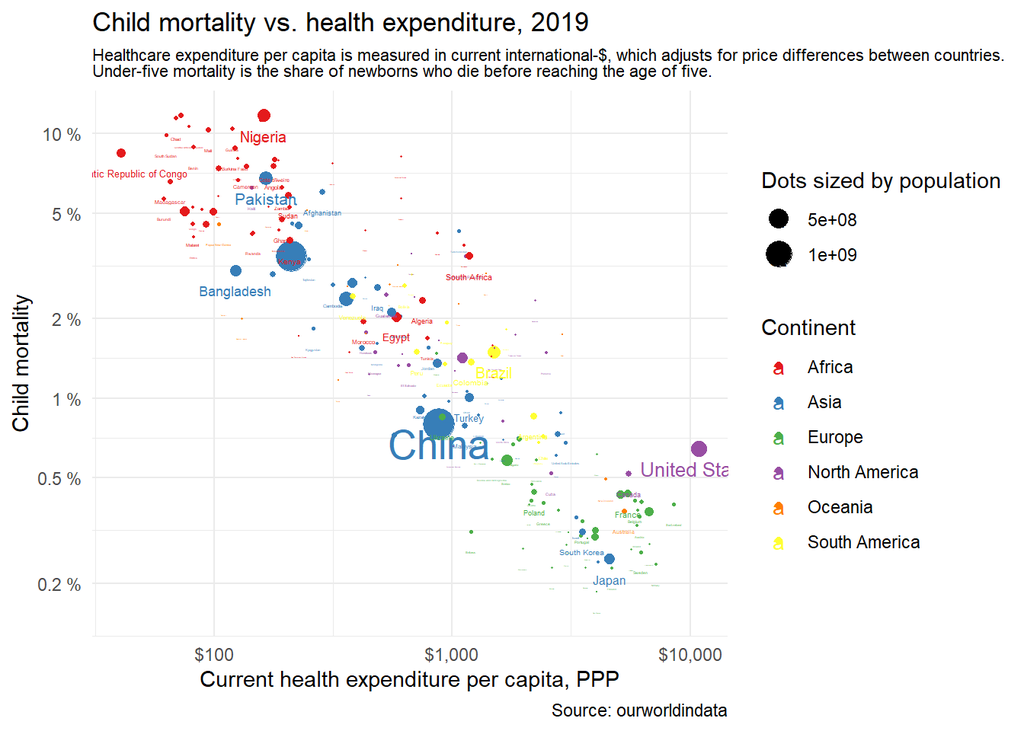

```r
# Plot
ggplot(data = dataset, aes(x = HealthExpenditure, y = ChildMortality, size = Population, color = Continent)) +
  geom_point(alpha = 0.7) +
  geom_point(show.legend = c(size = TRUE)) +
  geom_text(aes(label = Entity), nudge_y = -0.25, check_overlap = TRUE) + # Country name shows up on the plot
  scale_x_log10(labels = scales::dollar) + # Scale and log the x variable
  scale_y_continuous(breaks = c(0.2, 0.5, 1, 2, 5, 10), # Scale y
                     labels = function(breaks) paste(breaks, "%"),
                     trans = 'log2') +
  scale_colour_brewer(palette = "Set1") + # Colour
  scale_size(range = c(0, 7), name = "Dots sized by population") +
  labs(x = "Current health expenditure per capita, PPP",
       y = "Child mortality",
       title = "Child mortality vs. health expenditure, 2019",
       subtitle = "Healthcare expenditure per capita is measured in current international-$, which adjusts for price differences between countries.
Under-five mortality is the share of newborns who die before reaching the age of five.",
       caption = "Source: ourworldindata") +
       theme_minimal() +
       theme(
  legend.position = "right", # Legend on the right
  plot.subtitle = element_text(size = 8.3, lineheight = 0.8) # Adjust the subtitle text size and line spacing
)
```

### Task 2 - IMDb small multiples

The file [`imdb_series_df.csv`](https://github.com/intro-to-data-science-23/assignment-4-setup/blob/main/imdb_series_df.csv.zip) contains a data set on rating information on series and episodes from the InternetMovieDatabase. Use these data to create a small multiples plot that illustrates a relationship of your choice. You can work with the entire dataset or a subset. Your plot should adhere to the principles of good design. In addition to the visualization, provide a sound discussion (10 sentences or less) of what the plot might tell us.

*Note:* The data binary is fairly large (~93MB). It makes sense to download it first to your local drive and then import it into R. However, make sure that the file is not synced to GitHub using `.gitignore`.

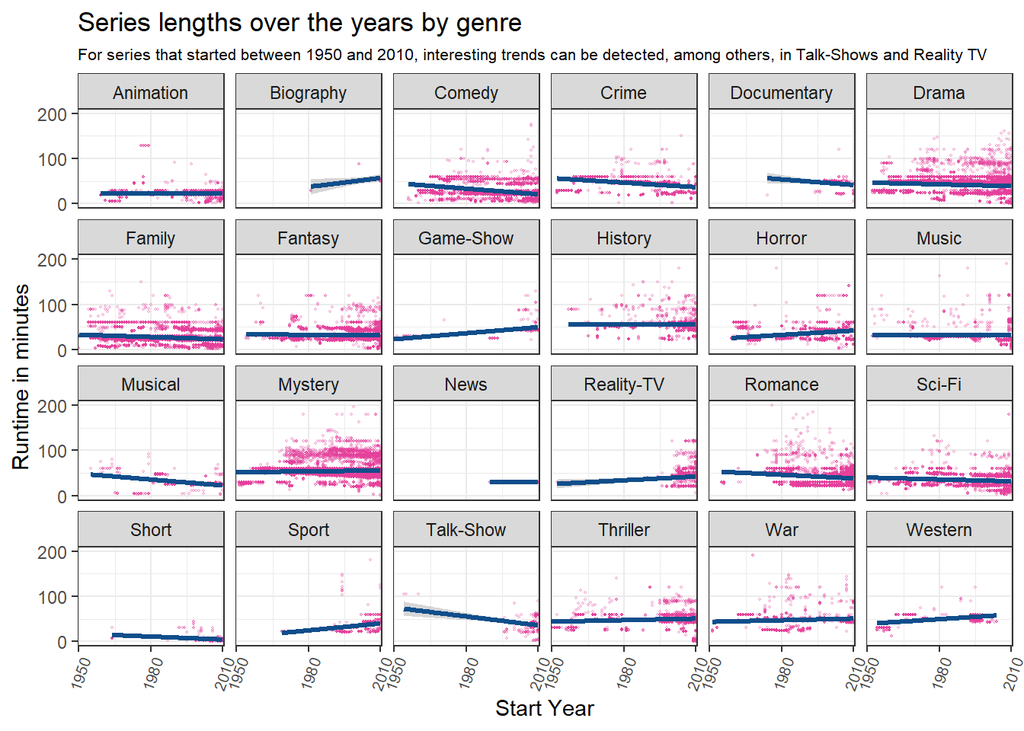

```r
imdb_series_df <- read_csv("imdb_series_df.csv/imdb_series_df.csv")
imdb_data <- imdb_series_df %>%
  separate(genres, c("genre1", "genre2", "genre3"), sep = ",") %>%  # Rearrange the dataset so that each genre is a column
  select(-"genre1", -"genre2") %>%  # Select only one column to work with for convenience and shorter runtimes
  drop_na()

plot_genres_runtime <- imdb_data %>%
  ggplot(aes(x = start_year, y = runtime_mins)) +  # Series lengths over the years
  geom_point(
    alpha = 0.2,
    color = "#e33e99", # observations
    size = 0.4) +
  geom_smooth(method = lm,
              linewidth = 1.2,
              colour = "dodgerblue4") + # axis
  scale_x_continuous(limits = c(1950, 2010),
                     breaks = c(1950, 1980, 2010),
                     expand = c(0.01,0.01)) +
  scale_y_continuous(limits = c(0, 200), breaks = c(0, 100, 200)) +
  labs(
    x = "Start Year",
    y = "Runtime in minutes",
    title = "Series lengths over the years by genre",
    subtitle = "For series that started between 1950 and 2010, interesting trends can be detected, among others, in Talk-Shows and Reality TV") + # Some findings
  facet_wrap(~ genre3, ncol = 6) + # ncol for order
  theme_bw() +
  theme(axis.text.x = element_text(angle = 70, hjust = 1, size = 7.5)) +
  theme(plot.subtitle = element_text(size = 8)) # Change subtitle size

plot_genres_runtime
```

The small multiples plots above shows the relationship between shows’ runtime in minutes and show’s starting year. The function facet_wrap() comes in handy to see how the relationship changes across genres. Some conclusions can be drawn. First of all, some genres have more observations than others. This can be due to the popularity of some genres over others, like Comedy over Biography, and to the data selection used in this analysis that reduced the amount of data analyzes (only selecting the third genre column). Second of all, some genres show positive or negative relationships between start year and runtime, while others show no relationships. Talk-shows runtime decreased as years go by; this might signal their decrease in popularity, the lack of demand and hence the decreased time to keep the audience interested. Westerns movies runtime increase as years go by, and the line interrupts at some points around the 2000s for lack of movies available. It is interesting to see how some genres, like reality tv and game shows, have most of their observations in the last 20 years as they’re both relatively new genres.

### Task 3 - Principles of good data visualization

On [slide 75 of the lecture slides (“Dos and”Don’ts”)](https://raw.githack.com/intro-to-data-science-22/lectures/main/09-visualization/09-visualization.html#85) you find a linked list of 20 statements expressing principles of good data visualization. Follow the links to learn more about them. Then, come up with another principle of good data visualization **that is not listed on the slide** and illustrate it following the instructions below:

1. Create a two-panel plot. The left panel shows a poorly designed plot (e.g., a 3D plot), the right panel shows a well-designed alternative using the same data. You are free to use whatever data you want to make your point.
2. The title of the plot should be the name of the principle, e.g. “**Don’t go 3D.**”
3. The bottom of the plot should provide a note that explains, in a few sentences, the principle illustrated in the plot and how the right is an improved over the left version.
4. Embed the plot in your `.Rmd` but also provide it as a `.png` or `.pdf` in your submission repo.

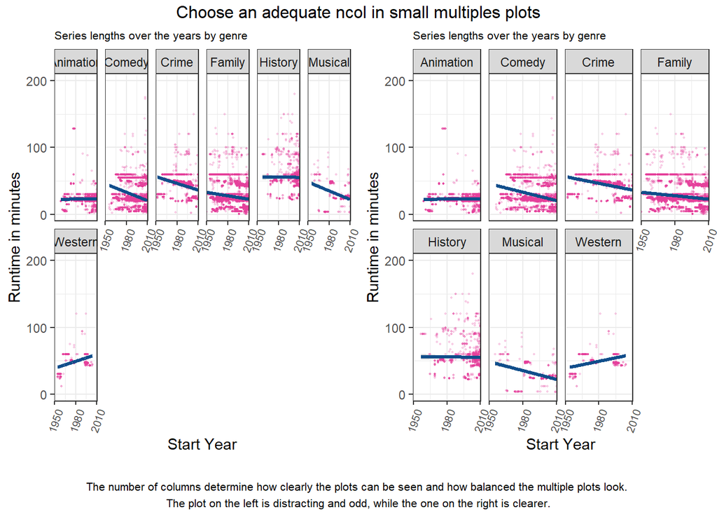

```r
# "Choose an adequate ncol in small multiples plots",
imdb_data <- imdb_series_df |>
  separate(genres, c("genre1", "genre2", "genre3"), sep = ",") |>
  select(-"genre1", -"genre2") |>
  drop_na() |>
  filter(genre3 %in% c("Animation", "Western", "Comedy", "Family", "History", "Crime",  "Musical")) #selecting some genres only for this example


plot_genres_runtime_bad <- imdb_data |>
  ggplot(aes(x = start_year, y = runtime_mins)) +
  geom_point(
    alpha = 0.2,
    color = "#e33e99",
    size = 0.4) +
  geom_smooth(method = lm,
              linewidth = 1.2,
              colour = "dodgerblue4") +
  scale_x_continuous(limits = c(1950, 2010),
                     breaks = c(1950, 1980, 2010),
                     expand = c(0.01,0.01)) +
  scale_y_continuous(limits = c(0, 200), breaks = c(0, 100, 200)) +
  labs(
    x = "Start Year",
    y = "Runtime in minutes",
    title = "Series lengths over the years by genre") +
  facet_wrap(~ genre3, ncol = 6) + # TOO BIG OF A NCOL FOR 7 SMALL PLOTS
  theme_bw() +
  theme(axis.text.x = element_text(angle = 70, hjust = 1, size = 7.5)) +
  theme(plot.title = element_text(size = 8)) # Change '12' to your desired size


plot_genres_runtime_good <- imdb_data |>
  ggplot(aes(x = start_year, y = runtime_mins)) +
  geom_point(
    alpha = 0.2,
    color = "#e33e99",
    size = 0.4) +
  geom_smooth(method = lm,
              linewidth = 1.2,
              colour = "dodgerblue4") +
  scale_x_continuous(limits = c(1950, 2010),
                     breaks = c(1950, 1980, 2010),
                     expand = c(0.01,0.01)) +
  scale_y_continuous(limits = c(0, 200), breaks = c(0, 100, 200)) +
  labs(
    x = "Start Year",
    y = "Runtime in minutes",
    title = "Series lengths over the years by genre") +
  facet_wrap(~ genre3, ncol = 4) +  # NCOL CHANGES HERE
  theme_bw() +
  theme(axis.text.x = element_text(angle = 70, hjust = 1, size = 7.5)) +
  theme(plot.title = element_text(size = 8)) # Change '12' to your desired size

bottom_text <- textGrob("
The number of columns determine how clearly the plots can be seen and how balanced the multiple plots look.
The plot on the left is distracting and odd, while the one on the right is clearer.",
                        gp = gpar(fontsize = 8))  # Adjust the fontsize as needed

two_panel_plot <- grid.arrange(plot_genres_runtime_bad,
             plot_genres_runtime_good,
             ncol = 2,
             top = "Choose an adequate ncol in small multiples plots",
             bottom = bottom_text)
```

```r
ggsave("two_panel_plot.png", two_panel_plot, width = 10)
```